# One-forms and Gradient

### **NOTES ON STATISTICS, PROBABILITY and MATHEMATICS**

### One-forms, Covectors & Gradient:

The following is simply a literal capture of the explanation found [here](http://www.physicsinsights.org/pbp_one_forms.html). Pictorially, this is nicely explained [here](https://youtu.be/LNoQ_Q5JQMY).

Fundamentally, a 1-form can be imagined to be a gradient. Cover the manifold with numbers. That’s a “scalar field”. The gradient is the rate at which those numbers are changing at each point.

Let our “scalar field” represent height. Then the “gradient” of the scalar field is exactly what we think of as a gradient in “real life”. When we look at a point on a hillside, the “gradient” is a measure of which way the hill slopes “up”, and how steep the slope is.

The most natural way to represent a gradient is as a series of contour lines. This is how gradients have been drawn on maps of the Earth for centuries. In more than two dimensions, the “contour lines” are actually hypersurfaces, but the principle is unchanged.

Locally, the best linear approximation of the contours is a collection of straight lines (or hyperplanes). At a particular point on the manifold, the local linear approximation to the contours is a “covector” (or dual vector) and it’s represented as a collection of hyperplanes in the tangent space at that point. On this page, all drawings are restricted to 2 dimensions, and the hyperplanes appear as straight lines.

Now, having given this description, I must hasten to add that, while every gradient is a 1-form, not all 1-forms are actually the gradients of functions. In particular, only “closed”, or curl-free, 1-forms are actually the gradients of functions. But for the purposes of understanding 1-forms and their action on vectors, it’s perfectly reasonable to think in terms of gradients. And the covector associated with a 1-form at each point is the same, whether or not the 1-form globally represents a gradient.

##### Definition of a Covector

A “covector” is a rank (0,1) tensor, also called a “dual vector”. It is a linear function which maps vectors into real numbers. The term “dual vector” is actually more popular than “covector” but seems cumbersome to me. “Covector” also suggests “covariant vector”, in contrast to ordinary vectors, which are “contravariant”.

A covector provides a way to measure a vector. If we visualize it, as Misner, Thorne, and Wheeler do, as a collection of parallel hyperplanes (see figure 1), then the length of a vector corresponds to the number of hyperplanes “pierced” by the vector.

[figure not shown]

Alternatively, we can view it as a “spatial frequency”. It’s a frequency and a direction. The length of a vector is then the number of wavecrests the vector crosses.

It’s worth pointing out that, if we were to multiply the covector by 2, we would double the number of blue lines – the distance between the lines would decrease if the magnitude of the covector increased. Once again, the covector is a spatial frequency; double it, and the density of wavecrests increases; the “wavelength”, on the other hand, decreases when we do that.

Taking the analogy one step farther, a covector is a frequency, a vector is like a wavelength, and their “product” is analagous to a velocity. Coordinates So far we’ve talked about covectors with no mention of coordinates. In a particular coordinate system, the “coordinates” of a covector are coefficients on the basis covectors, just as the “coordinates” of a vector are coefficients on the basis vectors. The “basis covector” corresponding to a particular “basis vector” is the covector which points in the same direction as that basis vector, and which has a wavelength exactly as long as the basis vector. No mention of a “metric” is made here; the metric doesn’t enter into it. (Under rigid rotations, the correspondence between basis vectors and basis covectors is fixed. However, if we allow more general transformations, then the correspondance is dependent on the chosen basis. In the absence of a metric, there is no distinguished “natural” isomorphism between covectors and vectors.)

##### 1-forms

A “1-form” is a covector field. In other words, a 1-form associates a covector with each point on the manifold – or each point in spacetime, if you prefer. Most of the time, no distinction is drawn between a 1-form and the covector associated with it at a particular point, and the term “covector” is, in fact, hardly ever used in some texts.

Throughout this website, I tend to use “1-form” to refer to both the covector field on the manifold, and the covector associated with that field at each point.

The dot product of a vector and a covector, or the result of applying a 1-form to a vector, is just the number of lines of the 1-form which the vector crosses. It’s the length of the vector, as measured by the 1-form.

If we look at the 1-form and the vector in a particular coordinate system, then we see that the total number of lines the vector crosses is just the number of lines it crosses in the direction of each basis vector in turn. It doesn’t matter what path you follow – you need to cross the same number of lines no matter how you go! The number of lines crossed in the direction of each basis vector is just the number of lines crossed by that basis vector, times the distance the vector travels in along that axis. In other words, it’s the product of the corresponding component of the vector, with the corresponding component of the covector.

Or, again in other words, it’s just the dot product of the vector and the covector.

It doesn’t matter how the axes are chosen.

In Cartesian space, under rigid rotations, the basis covectors are naturally isomorphic with the basis vectors, and each vector has a natural covector corresponding to it, which has the same components as the vector. In this case, we have just exhibited a simple visual proof that dot product is unaffected by rigid rotations.

#### Simple example with a contour or isobar plot:

A cartographic map shows the lines of equal vertical height in meters $\text{V}_{\text{m}}$, so that the density of these lines is a representation of the gradient, or change along any possible direction.

If one travels from right to left for a certain distance, e.g. $2$ miles represented by the red arrow in the direction towards the mountains, and strictly along the $x$ axis, and the spacing of the first two lines in the top plot is such that every line corresponds to a vertical climb of $10$ meters, starting at sea level, the calculation of the total vertical climb is a dot product:

$$\small
\begin{bmatrix}\text{V}_{\text{m}}\text{ along x}&
\text{V}_{\text{m}}\text{ along y}\end{bmatrix}\begin{bmatrix}\text{dist
travelled along x}\\ \text{dist travelled along
y}\end{bmatrix}=\begin{bmatrix}10 \,\frac{\text{vert
meters}}{\text{mile}}& \text{V}_{\text{m}}\text{ along
y}\end{bmatrix}\begin{bmatrix}2 \text{ miles}\\ 0\end{bmatrix}=20 \text{
vert meters}$$

This isoplot representing the gradient is a covector, and transforms covariantly under a change of basis, for example, from vertical meters to vertical centimeters, as shown in the second plot, which depicts a denser set of lines. Now,

As the basis vectors have decreased in magnitude (from m to cm), so has the spacing of the isolines.

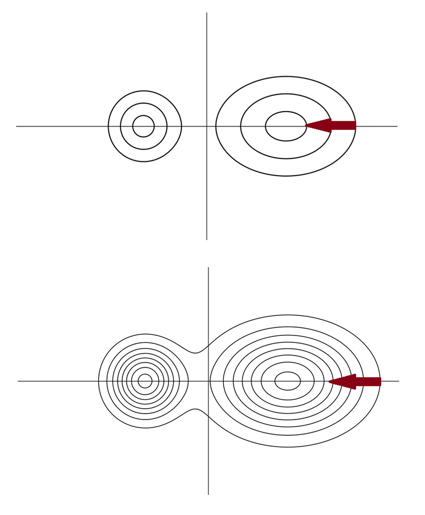

Imagine the drop in temperature per horizontal displacement when climbing down a step mountain:

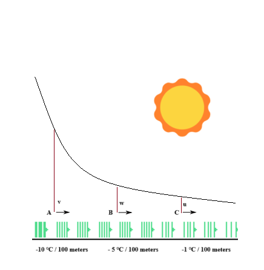

At point A a horizontal displacement vector of $100 \text{m}$ could be dotted with a covector respresenting the local drop in temperature per $100$ meters traveled horizontally, $- 10\; ^{ \circ}\text C/100\text{ m}$, symbolized as a stack of parallel lines of $10$ lines. The actual temperature drop is the number of parallel lines traversed by the vector, $- 10\; ^{ \circ}\text C$. This is equivalent to

$$\small
\begin{bmatrix}- 10\; ^{ \circ}\text C/100\text{ m} \text{ along x}&
0^{ \circ}\text C/100\text{ m}\text{ along
y}\end{bmatrix}\begin{bmatrix}100 \text{ meters along x}\\ \text{dist
traveled along y}\end{bmatrix}=-10^{ \circ}\text C$$

The same applies to points B and C.

The key observation now is to see that if instead of meters we used centimeters (changing basis vectors), the distance traveled would still be the same (the actual magnitude and orientation of the horizontal displacement vectors, $v, w, u,$ would be the same), but the components would transform contravariantly: the smaller basis vectors of $1$ cm in length would require the $x$ component of the vector to increase $10^2$ times, going from $\begin{bmatrix}100\\0\end{bmatrix}$ to $\begin{bmatrix}100\times\color{red}{10^2}\\0\end{bmatrix}$, while the stack of parallel lines would have to become $10^2$ times less dense, i.e. vary covariantly: the basis vector has decreased in magnitude, and so has the stack decreased in density, so that the dot product stays unchanged at $-10^{ \circ}\text C$. Now the covector is $\begin{bmatrix}- 10\; ^{ \circ}\text C \text{ / } 100\times\color{red}{10^2}\text{ m} \text{ along x}&& 0^{ \circ}\text C\end{bmatrix}$.

[Home Page](http://rinterested.github.io/statistics/index.html)

**NOTE: These are tentative notes on different topics for personal use - expect mistakes and misunderstandings.**